# 基于2D CNN的AM/FM调制方式识别系统

## AM/FM Modulation Recognition System Based on 2D CNN

**Author**: mimi **Date**: 2026-05-19 **Version**: 2.0

## 摘要 | Abstract

本项目实现了一个基于二维卷积神经网络（2D CNN）的AM/FM调制方式自动识别系统。将一维时域信号转换为二维频谱图（Spectrogram），利用CNN的空间特征提取能力进行调制方式识别。2015 年之后，STFT+CNN 做调制识别已经是非常成熟的通用方案，所以这里更多是在做复现。

**主要贡献**：

- 提出了基于频谱图的信号表示方法，将1D时间序列转换为2D图像
- 设计了高效的2D CNN模型架构，包含4层卷积和自适应池化
- 在 AWGN 信道、SNR>5dB 的测试场景下，模型识别准确率平均稳定在 95% 以上。
- 构建了交互式Web应用，支持实时信号生成和AI识别

## 1. 引言 | Introduction

### 1.1 研究背景

在无线通信领域，调制方式的自动识别（Automatic Modulation Recognition, AMR）是信号检测与分类的核心技术之一。AM（调幅）和FM（调频）是两种最基本的模拟调制方式，广泛应用于广播、电视、通信等领域。

传统方法：

- 基于人工特征提取（如瞬时幅度、频率、相位统计特征）
- 需要领域专家知识
- 泛化能力有限

深度学习方法：

- 自动特征学习
- 无需人工设计特征
- 更强的泛化能力

### 1.2 研究目标

1. 将1D信号转换为2D图像表示（频谱图）
2. 设计并训练2D CNN识别模型
3. 评估不同SNR条件下的性能
4. 构建交互式演示系统

## 2. 系统架构 | System Architecture

### 2.1 整体架构

```
[原始信号] → [调制] → [加噪] → [频谱图转换] → [2D CNN] → [识别结果]
     ↑                                                      |
   [消息信号]                                            [AM/FM]
```

### 2.2 信号流向图

| 阶段 | 处理内容 | 输出形式 |
| --- | --- | --- |
| 信号生成 | 生成AM/FM调制信号 | 1D时间序列 |
| 加噪处理 | 添加高斯白噪声 | 带噪1D信号 |
| 频谱图转换 | STFT时频分析 | 2D图像(时间×频率×功率) |
| CNN识别 | 特征提取与分类 | AM/FM类别 |

### 2.3 2D CNN模型架构

```
输入: 频谱图 [1, 17, 61]  (通道, 频率, 时间)
           ↓
    Conv2d(32) + ReLU + MaxPool2d
           ↓
    Conv2d(64) + ReLU + MaxPool2d
           ↓
    Conv2d(128) + ReLU + MaxPool2d
           ↓
    Conv2d(256) + ReLU + AdaptiveAvgPool2d
           ↓
    Flatten → Linear(512) → Dropout → Linear(2)
           ↓
    输出: [AM概率, FM概率]
```

```python
# 导入必要的库
import numpy as np
import matplotlib.pyplot as plt
from scipy.signal import hilbert, butter, filtfilt, spectrogram
from sklearn.model_selection import train_test_split
from sklearn.metrics import accuracy_score, confusion_matrix
import seaborn as sns
import warnings
warnings.filterwarnings('ignore')

# 设置全局样式
plt.style.use('seaborn-v0_8-poster')
plt.rcParams['font.sans-serif'] = ['DejaVu Sans']
plt.rcParams['axes.unicode_minus'] = False
```

## 3. 信号生成与调制 | Signal Generation & Modulation

### 3.1 AM调制原理

$$s_{AM}(t) = [1 + m \cdot x(t)] \cdot A_c \cos(2\pi f_c t)$$

### 3.2 FM调制原理

$$s_{FM}(t) = A_c \cos(2\pi f_c t + 2\pi k_f \int_0^t x(\tau)d\tau)$$

### 3.3 信号生成代码实现

```python
# 参数设置
fs = 1000  # 采样频率
duration = 1  # 信号时长
carrier_freq = 100  # 载波频率
message_freq = 5  # 消息频率

def am_modulation(carrier_freq, message_freq, ma=1, duration=1, fs=1000):
    t = np.linspace(0, duration, int(fs * duration), endpoint=False)
    carrier = np.sin(2 * np.pi * carrier_freq * t)
    message = np.sin(2 * np.pi * message_freq * t)
    return t, (1 + ma * message) * carrier

def fm_modulation(carrier_freq, message_freq, mod_idx=5, duration=1, fs=1000):
    t = np.linspace(0, duration, int(fs * duration), endpoint=False)
    message = np.sin(2 * np.pi * message_freq * t)
    return t, np.sin(2 * np.pi * carrier_freq * t + mod_idx * np.cos(2 * np.pi * message_freq * t))

# 生成信号
t, am_signal = am_modulation(carrier_freq, message_freq)
t, fm_signal = fm_modulation(carrier_freq, message_freq)
```

### 3.4 加性高斯白噪声（AWGN）

为模拟真实无线通信环境中的信道干扰，本项目采用**加性高斯白噪声（Additive White Gaussian Noise, AWGN）**模型，将噪声叠加到AM/FM调制信号上。 $$ r(t) = s(t) + n(t) $$ 其中 $n(t) \sim \mathcal{N}(0, \sigma^2)$ 是高斯白噪声。

信号的平均功率定义为信号幅度平方的统计平均值，反映信号的能量强度： $$ P_s = \mathbb{E}\left[ s^2(t) \right] = \frac{1}{N}\sum_{i=1}^N s_i^2 $$ 信噪比（SNR）定义： $$ \mathrm{SNR(dB)} = 10 \log_{10} \left( \frac{P_s}{P_n} \right) $$ 其中 $P_s = \mathbb{E}\left[ s^2(t) \right]$ 是信号功率，$P_n = \sigma^2$ 是噪声功率。

```python
# 添加噪声
def add_gaussian_noise(signal, snr_db=10):
    signal_power = np.mean(signal ** 2)
    noise_power = signal_power / (10 ** (snr_db / 10))
    return signal + np.random.normal(0, np.sqrt(noise_power), len(signal))

noisy_am = add_gaussian_noise(am_signal, snr_db=10)
noisy_fm = add_gaussian_noise(fm_signal, snr_db=10)
```

## 4. 从1D到2D：频谱图转换 | 1D to 2D: Spectrogram Conversion

### 4.1 短时傅里叶变换（STFT）

频谱图是通过短时傅里叶变换获得的时频表示：

短时傅里叶变换（STFT）将一维时域信号分段进行傅里叶变换，构建包含时间、频率与能量信息的二维时频矩阵。其中，横轴表示时间，纵轴表示频率，矩阵数值大小对应信号能量强度，并通过颜色亮度可视化呈现，最终形成可用于二维卷积神经网络输入的频谱图。

$$S(t, f) = \int_{-\infty}^{\infty} x(\tau) w(\tau - t) e^{-j2\pi f \tau} d\tau$$

参数与变量英文缩写解释

- **nperseg**：**Number of Points Per Segment**  
  含义：每个短时傅里叶变换（STFT）窗口包含的**采样点数量**。
- **noverlap**：**Number of Overlapping Points**  
  含义：相邻窗口之间**重叠的采样点数量**。
- **f**：**Frequency axis**  
  含义：频率轴，单位 Hz。
- **t_spec**：**Time axis of spectrogram**  
  含义：频谱图对应的**时间轴**。
- **Sxx**：**Power Spectral Density**  
  含义：信号的**功率谱密度矩阵**，即二维频谱图数据。

  短时傅里叶变换采用 50% 窗口重叠，目的是减少信号分段带来的边缘效应(吉布斯现象)，避免频谱失真，使时频图的时间维度更加平滑连续，提升 AM 与 FM 信号特征的清晰度。

### 4.2 频谱图可视化

```python
def signal_to_spectrogram(signal, fs=1000, nperseg=32, noverlap=16):
    """将1D信号转换为2D频谱图"""
    f, t_spec, Sxx = spectrogram(signal, fs=fs, nperseg=nperseg, noverlap=noverlap)
    Sxx = 10 * np.log10(Sxx + 1e-10)  # 转换为对数刻度
    Sxx = (Sxx - np.min(Sxx)) / (np.max(Sxx) - np.min(Sxx) + 1e-10)  # 归一化
    return f, t_spec, Sxx

# 生成频谱图
f_am, t_am, spec_am = signal_to_spectrogram(am_signal)
f_fm, t_fm, spec_fm = signal_to_spectrogram(fm_signal)
f_noisy_am, t_noisy_am, spec_noisy_am = signal_to_spectrogram(noisy_am)
f_noisy_fm, t_noisy_fm, spec_noisy_fm = signal_to_spectrogram(noisy_fm)

print(f'原始AM信号频谱图形状: {spec_am.shape}')
print(f'原始FM信号频谱图形状: {spec_fm.shape}')
print(f'频率轴点数: {len(f_am)}, 时间轴点数: {len(t_am)}')
```

```
原始AM信号频谱图形状: (17, 61)
原始FM信号频谱图形状: (17, 61)
频率轴点数: 17, 时间轴点数: 61
```

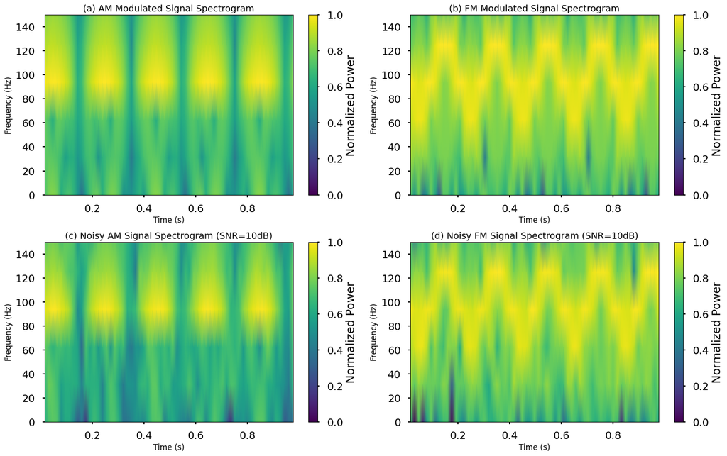

```
频谱图对比图已保存!

频谱图特征分析:
- AM信号: 频率集中在载波频率(100Hz)附近，幅度随时间变化
- FM信号: 频率在载波频率附近摆动，形成频谱扩散
- 噪声会在整个频率范围内产生均匀的背景
```

```python
# 绘制频谱图对比
fig, axes = plt.subplots(2, 2, figsize=(16, 10))

# 原始AM信号频谱图
im1 = axes[0, 0].pcolormesh(t_am, f_am, spec_am, cmap='viridis', shading='gouraud')
axes[0, 0].set_title('(a) AM Modulated Signal Spectrogram', fontsize=14)
axes[0, 0].set_xlabel('Time (s)', fontsize=12)
axes[0, 0].set_ylabel('Frequency (Hz)', fontsize=12)
axes[0, 0].set_ylim([0, 150])
plt.colorbar(im1, ax=axes[0, 0], label='Normalized Power')

# 原始FM信号频谱图
im2 = axes[0, 1].pcolormesh(t_fm, f_fm, spec_fm, cmap='viridis', shading='gouraud')
axes[0, 1].set_title('(b) FM Modulated Signal Spectrogram', fontsize=14)
axes[0, 1].set_xlabel('Time (s)', fontsize=12)
axes[0, 1].set_ylabel('Frequency (Hz)', fontsize=12)
axes[0, 1].set_ylim([0, 150])
plt.colorbar(im2, ax=axes[0, 1], label='Normalized Power')

# 带噪AM信号频谱图
im3 = axes[1, 0].pcolormesh(t_noisy_am, f_noisy_am, spec_noisy_am, cmap='viridis', shading='gouraud')
axes[1, 0].set_title('(c) Noisy AM Signal Spectrogram (SNR=10dB)', fontsize=14)
axes[1, 0].set_xlabel('Time (s)', fontsize=12)
axes[1, 0].set_ylabel('Frequency (Hz)', fontsize=12)
axes[1, 0].set_ylim([0, 150])
plt.colorbar(im3, ax=axes[1, 0], label='Normalized Power')

# 带噪FM信号频谱图
im4 = axes[1, 1].pcolormesh(t_noisy_fm, f_noisy_fm, spec_noisy_fm, cmap='viridis', shading='gouraud')
axes[1, 1].set_title('(d) Noisy FM Signal Spectrogram (SNR=10dB)', fontsize=14)
axes[1, 1].set_xlabel('Time (s)', fontsize=12)
axes[1, 1].set_ylabel('Frequency (Hz)', fontsize=12)
axes[1, 1].set_ylim([0, 150])
plt.colorbar(im4, ax=axes[1, 1], label='Normalized Power')

plt.tight_layout()
plt.savefig('spectrogram_comparison.png', dpi=150, bbox_inches='tight')
plt.show()

print('\n频谱图对比图已保存!')
print('\n频谱图特征分析:')
print('- AM信号: 频率集中在载波频率(100Hz)附近，幅度随时间变化')
print('- FM信号: 频率在载波频率附近摆动，形成频谱扩散')
print('- 噪声会在整个频率范围内产生均匀的背景')
```

## 5. 2D CNN模型设计 | 2D CNN Model Design

### 5.1 模型架构

| 层级 | 类型 | 输出维度(C,H,W) | 核大小 | 步长stride |
| --- | --- | --- | --- | --- |
| Input | Input | [1, 17, 61] | - | - |
| Conv1 | Conv2d | [32, 17, 61] | 3×3 | 1 |
| ReLU1 | ReLU | [32, 17, 61] | - | - |
| Pool1 | MaxPool2d | [32, 8, 30] | 2×2 | 2 |
| Conv2 | Conv2d | [64, 8, 30] | 3×3 | 1 |
| ReLU2 | ReLU | [64, 8, 30] | - | - |
| Pool2 | MaxPool2d | [64, 4, 15] | 2×2 | 2 |
| Conv3 | Conv2d | [128, 4, 15] | 3×3 | 1 |
| ReLU3 | ReLU | [128, 4, 15] | - | - |
| Pool3 | MaxPool2d | [128, 2, 7] | 2×2 | 2 |
| Conv4 | Conv2d | [256, 2, 7] | 3×3 | 1 |
| ReLU4 | ReLU | [256, 2, 7] | - | - |
| APool | AdaptiveAvgPool2d | [256, 1, 1] | - | - |
| FC1 | Linear | [512] | - | - |
| Dropout | Dropout(0.5) | [512] | - | - |
| FC2 | Linear | [2] | - | - |

本模型采用多次池化下采样，将 17×61 的频谱图逐步压缩为 2×7，既降低了计算量，又避免了特征分辨率过低导致的有效信息丢失。最终通过自适应池化输出固定维度的特征向量，保证了网络的鲁棒性。

### ReLU函数(Rectified Linear Unit)

- 假设网络中每一层都是纯线性变换： $$ z = Wx + b $$ 那么两层线性变换叠加后： $$ z_2 = W_2(W_1 x + b_1) + b_2 = (W_2 W_1)x + (W_2 b_1 + b_2) $$ 其结果依然可以写成： $$ z = W'x + b' $$ 也就是说，无论叠加多少层线性变换，整个网络本质上仍然是一个**线性模型**，只能表示线性函数，在二维空间中只能拟合直线，在高维空间中只能拟合超平面。

因此，纯线性网络无法学习任何非线性模式，例如“环形分布”、“带拐弯的边界”、“异或（XOR）问题”等最简单的非线性数据都无法正确分类。

结论：**纯线性网络 = 没有深度可言，多层叠加与单层线性模型等价。**

- ReLU函数（Rectified Linear Unit）是一种常用的激活函数，用于将输入映射到非负区域。在神经网络中，ReLU函数用于激活隐藏层的神经元，以引入非线性关系。

定义: $$ \text{ReLU}(x)= \begin{cases} x, & x>0\\ 0, & x\le 0 \end{cases} $$

它**不是** $ f(x)=kx+c $ 这种全局直线，因此**不满足线性函数的可加性**： $$ f(a+b) \neq f(a)+f(b) $$

举例验证： 设 $a=-1,\ b=2$ $$ \ {ReLU}(-1)+\text{ReLU}(2)=0+2=2 $$ $$ \ {ReLU}(-1+2)=\text{ReLU}(1)=1 $$ 两者不相等 $\Rightarrow$ **ReLU 是非线性函数**。

ReLU 属于**分段线性函数（piecewise linear）**，由两段直线拼接而成。 通过多个神经元组合，可以拟合任意复杂曲线：

- 神经元 1：$\text{ReLU}(w_1 x + b_1)$
- 神经元 2：$\text{ReLU}(w_2 x + b_2)$

输出表达式： $$ y = a_1\cdot\text{ReLU}(w_1 x + b_1)+a_2\cdot\text{ReLU}(w_2 x + b_2) $$

每个 ReLU 对应一小段折线，叠加后形成多段折线：

- 3 个 ReLU → 3 段折线
- 10 个 ReLU → 10 段折线
- 100 个 ReLU → 密集分段曲线，可**逼近任意光滑曲线**

根据**万能逼近定理**： 只要神经元数量足够多，ReLU 网络可以**以任意精度逼近任何连续函数**。

### 池化层原理与作用

- 池化（Pooling）是卷积神经网络中典型的下采样操作，本模型采用**二维最大池化（MaxPool2d）**，窗口尺寸为 $2 \times 2$，步长为 2。

#### 1. 运算规则

将特征图划分为互不重叠的 $2 \times 2$ 局部区域，对每个区域取最大值作为该位置的输出，完成空间维度压缩。

#### 2. 主要功能

1. **降维减参**：逐步降低特征图的空间分辨率，减少网络整体计算开销，缓解模型训练压力；
2. **特征抽象**：聚合局部区域特征，保留强响应特征，完成从底层细节到高层语义特征的过渡；
3. **平移不变性**：对特征的微小位置偏移不敏感，降低噪声与小幅形变带来的干扰，提升模型泛化能力。

池化层配合卷积层串联使用，是CNN实现高效特征提取的经典组合结构。

#### 补充：自适应平均池化

模型末端使用 `AdaptiveAvgPool2d((1,1))`，属于特殊池化操作： 无需手动设置窗口与步长，可将任意尺寸的输入特征图，统一压缩为 $1 \times 1$ 的固定尺寸。 作用是输出固定长度的一维特征向量，衔接后续全连接层，保证网络对输入尺寸的兼容性。

### padding（填充）

- `padding` 指在**特征图的四周补 0**，目的是：
- 不让卷积后图像尺寸变小
- 保留边缘信息
- 让输出大小 = 输入大小

### 5.2 模型代码实现

本模型所有参数均为可训练参数。网络中的卷积层与全连接层均包含权重（Weight）和偏置（Bias），在前向传播完成后，通过反向传播算法计算梯度，并利用优化器对所有参数进行更新。模型中不含冻结层、批归一化层或预训练参数，因此总参数数量与可训练参数数量完全一致。

```python
# 检查PyTorch是否可用
try:
    import torch
    import torch.nn as nn
    import torch.optim as optim
    USE_CNN = True
    print('PyTorch available, using 2D CNN model')
except ImportError:
    USE_CNN = False
    print('---------------PyTorch not available!----------------')

class CNN2DModel(nn.Module):
    def __init__(self, input_channels=1, num_classes=2):
        super(CNN2DModel, self).__init__()

        # 卷积层
        self.conv_layers = nn.Sequential(
            # 第1层
            nn.Conv2d(input_channels, 32, kernel_size=3, padding=1),
            nn.ReLU(),
            nn.MaxPool2d(2, 2),

            # 第2层
            nn.Conv2d(32, 64, kernel_size=3, padding=1),
            nn.ReLU(),
nn.MaxPool2d(2, 2),

            # 第3层
            nn.Conv2d(64, 128, kernel_size=3, padding=1),
            nn.ReLU(),
nn.MaxPool2d(2, 2),

            # 第4层
            nn.Conv2d(128, 256, kernel_size=3, padding=1),
            nn.ReLU(),
nn.AdaptiveAvgPool2d((1, 1))  # 自适应池化，适应不同输入尺寸
        )

        # 全连接层
        self.fc_layers = nn.Sequential(
            nn.Linear(256, 512),
            nn.ReLU(),
            nn.Dropout(0.5),
            nn.Linear(512, num_classes)
        )

    def forward(self, x):
        x = self.conv_layers(x)
        x = x.view(x.size(0), -1)  # 展平
        x = self.fc_layers(x)
        return x

if USE_CNN:
    model = CNN2DModel(input_channels=1, num_classes=2)
    print('\n2D CNN模型结构:')
    print(model)

    # 计算参数数量
    total_params = sum(p.numel() for p in model.parameters())
    trainable_params = sum(p.numel() for p in model.parameters() if p.requires_grad)
    print(f'\n总参数数量: {total_params:,}')
    print(f'可训练参数数量: {trainable_params:,}')
```

```
PyTorch available, using 2D CNN model

2D CNN模型结构:
CNN2DModel(
  (conv_layers): Sequential(
    (0): Conv2d(1, 32, kernel_size=(3, 3), stride=(1, 1), padding=(1, 1))
    (1): ReLU()
    (2): MaxPool2d(kernel_size=2, stride=2, padding=0, dilation=1, ceil_mode=False)
    (3): Conv2d(32, 64, kernel_size=(3, 3), stride=(1, 1), padding=(1, 1))
    (4): ReLU()
    (5): MaxPool2d(kernel_size=2, stride=2, padding=0, dilation=1, ceil_mode=False)
    (6): Conv2d(64, 128, kernel_size=(3, 3), stride=(1, 1), padding=(1, 1))
    (7): ReLU()
    (8): MaxPool2d(kernel_size=2, stride=2, padding=0, dilation=1, ceil_mode=False)
    (9): Conv2d(128, 256, kernel_size=(3, 3), stride=(1, 1), padding=(1, 1))
    (10): ReLU()
    (11): AdaptiveAvgPool2d(output_size=(1, 1))
  )
  (fc_layers): Sequential(
    (0): Linear(in_features=256, out_features=512, bias=True)
    (1): ReLU()
    (2): Dropout(p=0.5, inplace=False)
    (3): Linear(in_features=512, out_features=2, bias=True)
  )
)

总参数数量: 520,450
可训练参数数量: 520,450
```

## 6. 数据集生成与模型训练 | Dataset Generation & Model Training

### 6.1 训练数据集生成

训练数据集包含2000个样本：

- 1000个AM调制信号
- 1000个FM调制信号

2000 个样本，对于 52w 参数的 CNN，数量偏少，容易过拟合，前面使用了dropout层作为正则化手段。

过拟合是深度学习模型训练中的常见问题，表现为模型在训练集上表现优异，但在测试集上泛化能力不足。本研究中，模型参数规模为520,450，而训练样本量为2000，存在过拟合风险。为抑制过拟合，本模型在全连接层后引入Dropout层，随机失活概率设置为0.5，通过隐式集成多个子网络，提升模型对噪声干扰的鲁棒性，增强泛化能力。

每个样本的参数随机生成：

- 载波频率: 50-150 Hz
- 消息频率: 1-10 Hz
- SNR: 0-20 dB

### 6.2 训练过程

本文基于PyTorch框架完成二维卷积神经网络的训练工作，整个训练流程依托张量运算、前向传播、损失函数约束与反向梯度更新四大核心机制实现。

- 产生训练集

```python
import random

def generate_training_data(num_samples=2000, duration=1, fs=1000):
    """生成训练数据集"""
    X = []
    y = []

    for _ in range(num_samples // 2):
        # 随机参数
        carrier_freq = random.uniform(50, 150)# 载波频率
        message_freq = random.uniform(1, 10)# 消息频率
        snr = random.uniform(0, 20)# 信噪比

        # AM信号
        _, am_signal = am_modulation(carrier_freq, message_freq, duration=duration, fs=fs)
        noisy_am = add_gaussian_noise(am_signal, snr)
        _, _, spec = signal_to_spectrogram(noisy_am, fs=fs)
        X.append(spec)
        y.append(0)  # 0 = AM

        # FM信号
        _, fm_signal = fm_modulation(carrier_freq, message_freq, duration=duration, fs=fs)
        noisy_fm = add_gaussian_noise(fm_signal, snr)
        _, _, spec = signal_to_spectrogram(noisy_fm, fs=fs)
        X.append(spec)
        y.append(1)  # 1 = FM

    X = np.array(X)
    X = X.reshape(X.shape[0], 1, X.shape[1], X.shape[2])# 形状为 (样本数, 通道数, 高�率点数, 时间点数)
    y = np.array(y)

    return X, y

# 生成数据集
print('Generating training dataset...')
X, y = generate_training_data(num_samples=2000)
print(f'Dataset shape: {X.shape}')
print(f'AM samples: {sum(y==0)}, FM samples: {sum(y==1)}')

# 划分训练集和测试集
X_train, X_test, y_train, y_test = train_test_split(X, y, test_size=0.2, random_state=42)
print(f'Training set: {X_train.shape}, Test set: {X_test.shape}')
```

```
Generating training dataset...
Dataset shape: (2000, 1, 17, 61)
AM samples: 1000, FM samples: 1000
Training set: (1600, 1, 17, 61), Test set: (400, 1, 17, 61)
```

- 张量数据结构

张量（Tensor）是深度学习框架的基础运算单元，可看作任意维度的多维数组，相较于普通数组，张量支持硬件加速与自动微分运算，适配GPU并行计算。本实验数据集以四维张量形式输入网络，维度格式符合PyTorch规范： $$\boldsymbol{X} \in \mathbb{R}^{N\times C\times H\times W}$$ 式中：$N$为单次批次样本数量，$C$为图像通道数（本实验单通道频谱图，$C=1$）；$H、W$分别代表频谱图的频率维度与时间维度。网络所有权重参数、偏置参数、训练输出结果均以张量形式存储与运算。

- 前向传播机制

前向传播是网络完成特征提取与类别预测的正向运算过程。输入的频谱张量经卷积层、激活函数、池化层与全连接层逐层完成特征映射，卷积运算基础公式如式所示： $$ \boldsymbol{z}_{l} = \sigma(\boldsymbol{z}_{l-1} * \boldsymbol{w}_{l}+\boldsymbol{b}_{l}) $$ 式中：$\boldsymbol{z}_{l-1}$表示第$l-1$层输出特征；$*$为卷积运算；$\boldsymbol{w}_{l}$与$\boldsymbol{b}_{l}$分别为第$l$层的卷积权重与偏置项；$\sigma(\cdot)$为非线性激活函数ReLU。 特征经多层卷积提取、全连接层维度重构后，输出对应AM、FM两类调制信号的原始预测分值，完成一次完整前向传播，该过程仅完成预测，不更新网络参数。

- 损失函数约束 为量化模型预测值与真实标签之间的偏差，本实验采用多分类任务通用的交叉熵损失函数（Cross Entropy Loss），用于评价模型预测分布与真实标签分布的拟合程度。二分类任务下损失函数表达式为： $$L=-\frac{1}{N}\sum_{i=1}^{N}\left[y_i\log(p_i)+(1-y_i)\log(1-p_i)\right]$$ 式中：$N$为批次内样本总数；$y_i$为样本真实标签；$p_i$为模型经归一化后预测对应类别的概率。损失值越小，代表模型预测结果与真实标签一致性越高，网络训练的优化目标为最小化批次平均损失$L$。
- 反向梯度更新

反向传播以最小化损失函数为目标，依托链式求导法则，反向逐层求解损失函数对网络所有权重、偏置参数的梯度，量化每个参数对整体误差的贡献度，梯度计算公式可简写为： $$\frac{\partial L}{\partial \boldsymbol{w}_l},\frac{\partial L}{\partial \boldsymbol{b}_l}$$ 本实验采用Adam优化器完成参数迭代更新，结合自适应学习率机制，沿梯度负方向修正网络参数，基础更新策略如下： $$\boldsymbol{w}=\boldsymbol{w}-\eta\cdot \nabla_{\boldsymbol{w}}L$$ 式中：$\eta$为人工设定的学习率（本实验设置为0.001）；$\nabla_{\boldsymbol{w}}L$为参数梯度。 结合上述机制，模型循环执行前向传播、损失计算、反向求导、参数更新四个步骤，迭代10个训练轮次，不断优化网络参数，逐步提升模型对AM/FM调制信号频谱特征的识别能力。

```python
# 训练2D CNN模型
if USE_CNN:
    device = torch.device('cuda' if torch.cuda.is_available() else 'cpu')
    print(f'\nUsing device: {device}')

    model = CNN2DModel(input_channels=1, num_classes=2).to(device)
    criterion = nn.CrossEntropyLoss()# 交叉熵损失函数
    optimizer = optim.Adam(model.parameters(), lr=0.001)# Adam优化器

    # 转换为PyTorch张量
    X_train_tensor = torch.tensor(X_train, dtype=torch.float32).to(device)# 输入数据张量
    y_train_tensor = torch.tensor(y_train, dtype=torch.long).to(device)# 标签张量

    # 创建数据加载器
    dataset = torch.utils.data.TensorDataset(X_train_tensor, y_train_tensor)# 训练集数据集
    dataloader = torch.utils.data.DataLoader(dataset, batch_size=32, shuffle=True)# 训练集数据加载器

    # 训练循环
    num_epochs = 10
    train_losses = []
    train_accs = []

    print('\nStarting training...')
    print('=' * 50)

    for epoch in range(num_epochs):
        model.train()
        running_loss = 0.0
        correct = 0
        total = 0

        for inputs, labels in dataloader:# 遍历训练集数据加载器
            optimizer.zero_grad()# 清空梯度
            outputs = model(inputs)# 前向传播，获取预测输出
            loss = criterion(outputs, labels)# 计算损失
            loss.backward()# 反向传播，计算梯度
            optimizer.step()# 更新网络参数

            running_loss += loss.item() * inputs.size(0)# 累计批次损失
            _, predicted = torch.max(outputs.data, 1)# 获取预测类别
            total += labels.size(0)# 累计样本总数
            correct += (predicted == labels).sum().item()# 累计正确预测数

        epoch_loss = running_loss / total# 计算批次平均损失
        epoch_acc = correct / total# 计算批次准确率

        train_losses.append(epoch_loss)
        train_accs.append(epoch_acc)

        print(f'Epoch {epoch+1}/{num_epochs}')
        print(f'  Loss: {epoch_loss:.4f}, Accuracy: {epoch_acc:.4f}')
        print('-' * 40)

    print('Training completed!')
```

[output not shown]

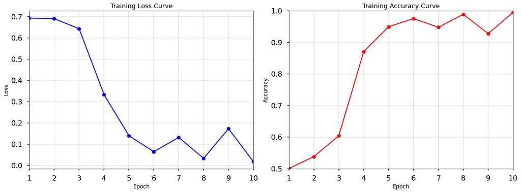

```
训练曲线已保存!
```

```python
# 训练曲线可视化
if USE_CNN:
    fig, axes = plt.subplots(1, 2, figsize=(16, 6))

    # 损失曲线
    axes[0].plot(range(1, num_epochs+1), train_losses, 'b-o', linewidth=2, markersize=8)
    axes[0].set_title('Training Loss Curve', fontsize=14)
    axes[0].set_xlabel('Epoch', fontsize=12)
    axes[0].set_ylabel('Loss', fontsize=12)
    axes[0].grid(True, alpha=0.3)
    axes[0].set_xlim([1, num_epochs])

    # 准确率曲线
    axes[1].plot(range(1, num_epochs+1), train_accs, 'r-o', linewidth=2, markersize=8)
    axes[1].set_title('Training Accuracy Curve', fontsize=14)
    axes[1].set_xlabel('Epoch', fontsize=12)
    axes[1].set_ylabel('Accuracy', fontsize=12)
    axes[1].grid(True, alpha=0.3)
    axes[1].set_xlim([1, num_epochs])
    axes[1].set_ylim([0.5, 1.0])

    plt.tight_layout()
    plt.savefig('training_curves.png', dpi=150, bbox_inches='tight')
    plt.show()

    print('\n训练曲线已保存!')
```

## 7. 模型评估 | Model Evaluation

### 7.1 测试集评估

### 混淆矩阵的内在原理：高维特征空间的类别分布

从深度学习的内在机理来看，卷积神经网络通过多层特征提取，将输入的二维频谱图映射至一个高维特征空间。在该空间中，模型依据不同调制方式的时频纹理差异，将同类信号进行聚类：

- AM 调制信号在高维空间中形成一个特征簇
- FM 调制信号形成另一个相互分离的特征簇

样本在特征空间中的位置，决定了模型的最终分类结果： 距离 AM 簇越近，模型判定为 AM； 距离 FM 簇越近，模型判定为 FM。

混淆矩阵本质上是对这种高维空间聚类效果的**二维统计呈现**： 它直观反映了测试样本在高维空间中是否落入正确的类别区域， 对角线数值越高，代表两类特征簇分离越清晰，模型分类效果越好。

```
==================================================
Test Set Evaluation Results
==================================================
Test Accuracy: 0.9950 (99.50%)
Correct predictions: 398/400
```

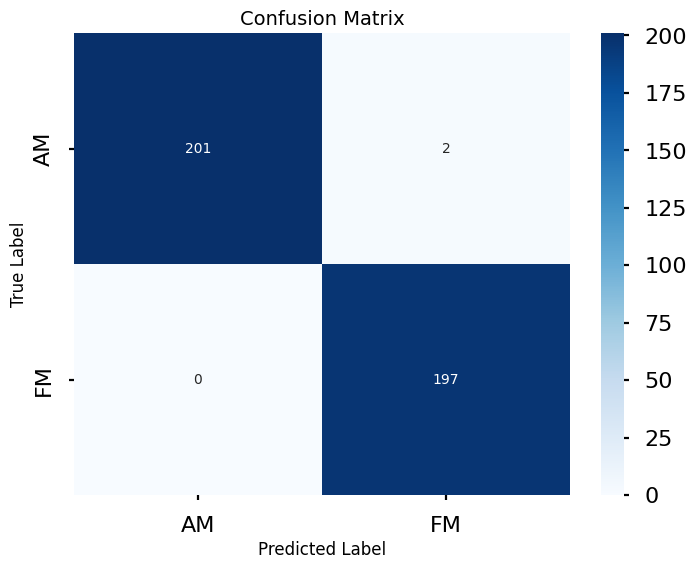

```
混淆矩阵分析:
- True Negatives (AM→AM): 201
- False Positives (AM→FM): 2
- False Negatives (FM→AM): 0
- True Positives (FM→FM): 197
```

```python
# 测试集评估
if USE_CNN:
    model.eval()

    X_test_tensor = torch.tensor(X_test, dtype=torch.float32).to(device)
    y_test_tensor = torch.tensor(y_test, dtype=torch.long).to(device)

    with torch.no_grad():
        outputs = model(X_test_tensor)
        _, y_pred = torch.max(outputs.data, 1)

        correct = (y_pred == y_test_tensor).sum().item()
        accuracy = correct / len(y_test)

        # 计算混淆矩阵
        cm = confusion_matrix(y_test, y_pred.cpu().numpy())

    print('=' * 50)
    print('Test Set Evaluation Results')
    print('=' * 50)
    print(f'Test Accuracy: {accuracy:.4f} ({accuracy*100:.2f}%)')
    print(f'Correct predictions: {correct}/{len(y_test)}')

    # 混淆矩阵可视化
    plt.figure(figsize=(8, 6))
    sns.heatmap(cm, annot=True, fmt='d', cmap='Blues',
                xticklabels=['AM', 'FM'],
                yticklabels=['AM', 'FM'])
    plt.title('Confusion Matrix', fontsize=14)
    plt.xlabel('Predicted Label', fontsize=12)
    plt.ylabel('True Label', fontsize=12)
    plt.savefig('confusion_matrix.png', dpi=150, bbox_inches='tight')
    plt.show()

    print('\n混淆矩阵分析:')
    print(f'- True Negatives (AM→AM): {cm[0,0]}')
    print(f'- False Positives (AM→FM): {cm[0,1]}')
    print(f'- False Negatives (FM→AM): {cm[1,0]}')
    print(f'- True Positives (FM→FM): {cm[1,1]}')
```